# act_report

## Report: act_report

- Create a **250-word-minimum written report** called "act_report.pdf" or "act_report.html" that communicates the insights and displays the visualization(s) produced from your wrangled data. This is to be framed as an external document, like a blog post or magazine article, for example.

### DATA WRANGLING PROJECT - Nyaradzo Majari

After gathering the data, i assessed both visually and programmatically. I managed to get some quality and tideness isssues. i cleaned the quality issues and also dealt with the tideness issues by merging some columns as as merging 3 dataframes into one. By so doing it make it easier to analyse and visualize the data and look from some answers from the data.

Below are some of the visualizations i made from the dataset about dogs, tweet_counts, retweet_count.

The fisrt question was: Is there any relationship between retweet_count and favorite_counts. And the following image shows the image showing a scatter plot. The relationship is positive and quite strong. The correlationship is excatly 0.7

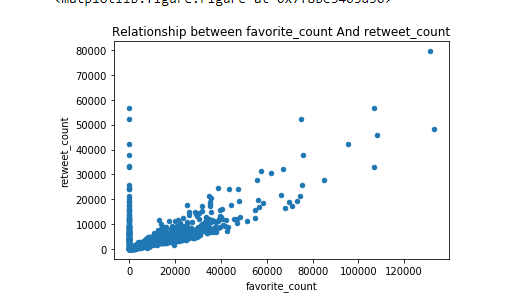

[figure not shown]